# Project1 by PUQI SONG

## This project aims to analyze textual descriptions of happy moments provided by interviewees and identify happiness keywords specific to different demographic groups. First, we create word clouds for all the text to showcase happiness keywords commonly recognized by the majority of people. Next, we segment the population based on characteristics such as nationality, age, marital history, gender, and whether they have children, and for each group, we calculate TF-IDF to reveal top-10 happiness keywords unique to that specific demographic.

```r
library(tm)
library(tidytext)
library(purrr)
library(DT)
library(stringr)
library(wordcloud2)
library(dplyr)
library(jiebaRD)
library(jiebaR)
library(NLP)
library(ggplot2)
library(ggpubr)
```

## Combine and clean the data

```r
setwd("E:/GitHub/ads-fall2023-project1-PuQi1/data")

original_data=read.csv('original_hm.csv',na.strings='NA')
demo_data=read.csv('demographic.csv',na.strings='NA')

hm_data=merge(original_data,demo_data,
              by='wid',all.x=T)

hm_data[hm_data == ''] = NA
clear_data=na.omit(hm_data)
clear_data=clear_data %>% distinct(hm,.keep_all = TRUE)
clear_data$hm=tolower(clear_data$hm)
clear_data$hm=str_replace_all(clear_data$hm,'[[:punct:]]', '')
write.csv(clear_data,'clear_data.csv')
```

## Remove stopwords

```r
stopwords=read.csv('C:/Users/spq/Desktop/stop.csv',head=T)

mix=worker('mix')
seg=segment(clear_data$hm,mix)

result=removeWords(seg,stopwords[,2])
df=freq(result)

for (i in c(0:100)){
  df=filter(df, df$char!=as.character(i))
}

finaldata=df[-15678,]
```

## Print wordcloud of all words

```r
finaldata=finaldata[order(-finaldata$freq),]
finaldata=finaldata[1:100,]
```

```r
wordcloud2(finaldata,shape= "circle",size=0.5)
```

[interactive chart not shown]

## In the picture, the larger the word, the more frequently it appears in the sentences of the interviewees. It can be seen that for most people, spending time with ‘friends’ and ‘family’ is joyful, enjoying a great ‘dinner’ or ‘trip’ also brings moments of happiness. Additionally, having a good ‘job’ or being part of a great ‘team’ is something that makes people happy.

## 1. group by gender

```r
data_g = as.data.frame(matrix(nrow=96362,ncol=2))
data_g[,1]=clear_data$gender
data_g[,2]=clear_data$hm

GID <- data_g$V1[!duplicated(data_g$V1)]
GO <- matrix(NA,nrow=length(GID),ncol=2)
for (i in 1:length(GID)) {
  a <- data_g[data_g$V1==GID[i],]
  GO[i,1] <- a[1,1]
  GO[i,2] <- paste(a[,2],collapse = ",")
}
GO_g <- as.data.frame(GO)

corpus_g=VCorpus(VectorSource(GO_g$V2))

list_g=corpus_g%>%
  tidy()%>%
  select(text)

dict_g <- tidy(corpus_g) %>%
  select(text) %>%
  unnest_tokens(dictionary, text)
completed_g <- list_g %>%
  mutate(id = row_number()) %>%
  distinct()%>%
  unnest_tokens(stems, text)%>%
  bind_cols(dict_g) %>%
  anti_join(stopwords, by = c("dictionary" = "word"))
completed_g$dictionary<-NULL

g_1=as.data.frame(table(completed_g[completed_g$id==1,2]))
g1_1=left_join(completed_g[completed_g$id==1,],g_1,
              by='stems')

g_2=as.data.frame(table(completed_g[completed_g$id==2,2]))
g1_2=left_join(completed_g[completed_g$id==2,],g_2,
               by='stems')

gg=rbind.data.frame(g1_1,g1_2)
gg=gg[!duplicated(gg), ]
gg %>%
  bind_tf_idf(term = stems,document = id,n = Freq) -> tf_idf_gg


tf_idf_gg=tf_idf_gg[tf_idf_gg$stems!='3mth',]
tf_idf_gg=tf_idf_gg[tf_idf_gg$stems!='ï',]
tf_idf_gg=tf_idf_gg[tf_idf_gg$stems!='rs350',]


tf_idf_gg%>%
  group_by(id) %>%
  arrange(desc(tf_idf))%>%
  slice(1:10) ->ggfinal
ggfinal
```

| id | stems | Freq | tf | idf | tf_idf |
| --- | --- | --- | --- | --- | --- |
| 1 | spurs | 21 | 6.431361e-05 | 0.6931472 | 4.457879e-05 |
| 1 | prominent | 20 | 6.125105e-05 | 0.6931472 | 4.245599e-05 |
| 1 | furious | 19 | 5.818850e-05 | 0.6931472 | 4.033319e-05 |
| 1 | headset | 19 | 5.818850e-05 | 0.6931472 | 4.033319e-05 |
| 1 | wayanad | 19 | 5.818850e-05 | 0.6931472 | 4.033319e-05 |
| 1 | massive | 18 | 5.512595e-05 | 0.6931472 | 3.821040e-05 |
| 1 | yankees | 18 | 5.512595e-05 | 0.6931472 | 3.821040e-05 |
| 1 | guns | 17 | 5.206339e-05 | 0.6931472 | 3.608760e-05 |
| 1 | smash | 16 | 4.900084e-05 | 0.6931472 | 3.396480e-05 |
| 1 | experiential | 16 | 4.900084e-05 | 0.6931472 | 3.396480e-05 |

[output cut: 10 more lines]

## The table above provides the top ten words in each category based on their TF-IDF scores.

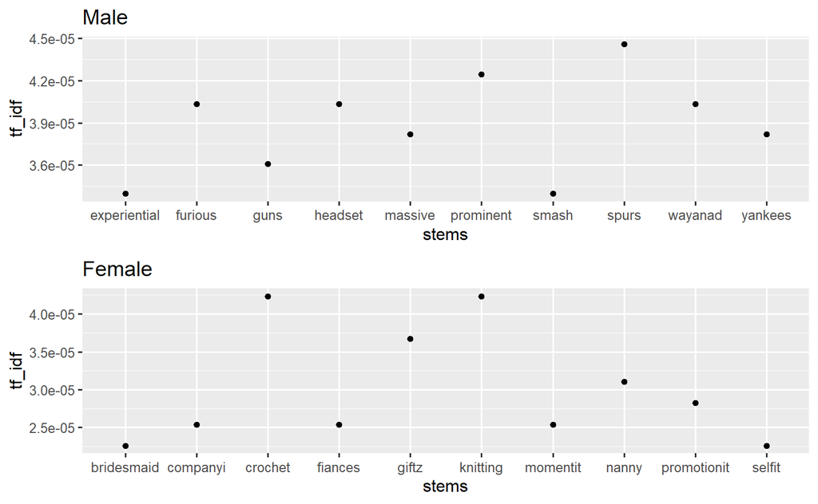

```r
p1=ggplot(ggfinal[1:10,],aes(x = stems,y=tf_idf))+geom_point()+
  ggtitle("Male")
p2=ggplot(ggfinal[11:20,],aes(x = stems,y=tf_idf))+geom_point()+
  ggtitle("Female")
ggarrange(p1,p2,ncol = 1,nrow =2,widths = c(1,1),heights = c(1,1,1))
```

## From the picture, it can be observed that what makes men and women happy differs. For example, men tend to prefer content and places like “gun” and “Wayanad” that can make them feel “furious,” while women prefer engaging in activities such as “knitting” and “crochet” as handicrafts.

## 2.group by country

```r
data_c = as.data.frame(matrix(nrow=96362,ncol=2))
data_c[,1]=clear_data$country
data_c[,2]=clear_data$hm

GID <- data_c$V1[!duplicated(data_c$V1)]
GO <- matrix(NA,nrow=length(GID),ncol=2)
for (i in 1:length(GID)) {
  a <- data_c[data_c$V1==GID[i],]
  GO[i,1] <- a[1,1]
  GO[i,2] <- paste(a[,2],collapse = ",")
}
GO_c <- as.data.frame(GO)

corpus_c=VCorpus(VectorSource(GO_c$V2))

list_c=corpus_c%>%
  tidy()%>%
  select(text)

dict_c<- tidy(corpus_c) %>%
  select(text) %>%
  unnest_tokens(dictionary, text)
completed_c<- list_c%>%
  mutate(id = row_number()) %>%
  distinct()%>%
  unnest_tokens(stems, text)%>%
  bind_cols(dict_c) %>%
  anti_join(stopwords, by = c("dictionary" = "word"))
completed_c$dictionary<-NULL

c_1=as.data.frame(table(completed_c[completed_c$id==1,2]))
c1_1=left_join(completed_c[completed_c$id==1,],c_1,
               by='stems')

c_2=as.data.frame(table(completed_c[completed_c$id==2,2]))
c1_2=left_join(completed_c[completed_c$id==2,],c_2,
               by='stems')

cc=rbind.data.frame(c1_1,c1_2)
cc=cc[!duplicated(cc), ]
cc %>%
  bind_tf_idf(term = stems,document = id,n = Freq) -> tf_idf_cc

tf_idf_cc=tf_idf_cc[tf_idf_cc$stems!='3mth',]
tf_idf_cc=tf_idf_cc[tf_idf_cc$stems!='rs',]

tf_idf_cc%>%
  group_by(id) %>%
  arrange(desc(tf_idf))%>%
  slice(1:10) ->ccfinal
ccfinal
```

| id | stems | Freq | tf | idf | tf_idf |
| --- | --- | --- | --- | --- | --- |
| 1 | baseball | 371 | 0.0008663083 | 0.6931472 | 0.0006004792 |
| 1 | netflix | 217 | 0.0005067086 | 0.6931472 | 0.0003512237 |
| 1 | steak | 170 | 0.0003969607 | 0.6931472 | 0.0002751522 |
| 1 | starbucks | 136 | 0.0003175685 | 0.6931472 | 0.0002201217 |
| 1 | sushi | 121 | 0.0002825426 | 0.6931472 | 0.0001958436 |
| 1 | taxes | 98 | 0.0002288362 | 0.6931472 | 0.0001586171 |
| 1 | vegas | 98 | 0.0002288362 | 0.6931472 | 0.0001586171 |
| 1 | salad | 91 | 0.0002124907 | 0.6931472 | 0.0001472873 |
| 1 | donuts | 88 | 0.0002054855 | 0.6931472 | 0.0001424317 |
| 1 | nintendo | 87 | 0.0002031505 | 0.6931472 | 0.0001408132 |

[output cut: 10 more lines]

## The table above provides the top ten words in each category based on their TF-IDF scores.

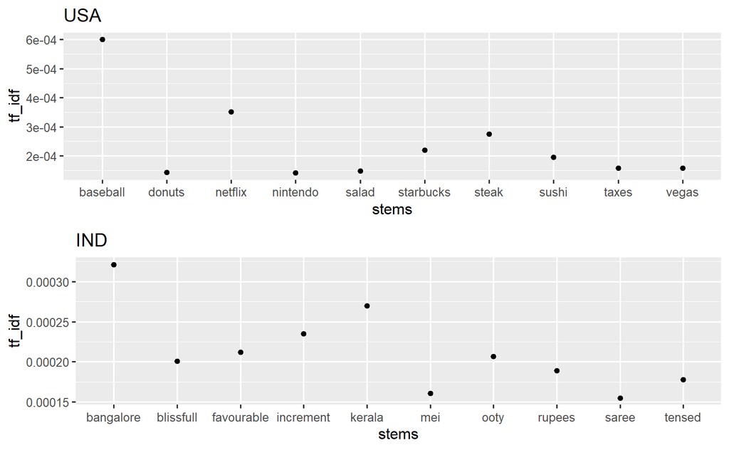

```r
p1=ggplot(ccfinal[1:10,],aes(x = stems,y=tf_idf))+geom_point()+
  ggtitle("USA")
p2=ggplot(ccfinal[11:20,],aes(x = stems,y=tf_idf))+geom_point()+
  ggtitle("IND")
ggarrange(p1,p2,ncol = 1,nrow =2,widths = c(1,1),heights = c(1,1,1))
```

## From the picture, it can be seen that people from different countries have different preferences for things they like. For example, Americans enjoy playing “baseball,” eating “donuts,” and drinking “Starbucks,” while Indians prefer wearing “saree” and earning “rupees.”

## 3. group by marriage

```r
data_m = as.data.frame(matrix(nrow=96362,ncol=2))
data_m[,1]=clear_data$marital
data_m[,2]=clear_data$hm

GID <- data_m$V1[!duplicated(data_m$V1)]
GO <- matrix(NA,nrow=length(GID),ncol=2)
for (i in 1:length(GID)) {
  a <- data_m[data_m$V1==GID[i],]
  GO[i,1] <- a[1,1]
  GO[i,2] <- paste(a[,2],collapse = ",")
}
GO_m <- as.data.frame(GO)

corpus_m=VCorpus(VectorSource(GO_m$V2))

list_m=corpus_m%>%
  tidy()%>%
  select(text)

dict_m <- tidy(corpus_m) %>%
  select(text) %>%
  unnest_tokens(dictionary, text)
completed_m<- list_m %>%
  mutate(id = row_number()) %>%
  distinct()%>%
  unnest_tokens(stems, text)%>%
  bind_cols(dict_m) %>%
  anti_join(stopwords, by = c("dictionary" = "word"))
completed_m$dictionary<-NULL

m_1=as.data.frame(table(completed_m[completed_m$id==1,2]))
m1_1=left_join(completed_m[completed_m$id==1,],m_1,
               by='stems')

m_2=as.data.frame(table(completed_m[completed_m$id==2,2]))
m1_2=left_join(completed_m[completed_m$id==2,],m_2,
               by='stems')

m_3=as.data.frame(table(completed_m[completed_m$id==3,2]))
m1_3=left_join(completed_m[completed_m$id==3,],m_3,
               by='stems')

m_4=as.data.frame(table(completed_m[completed_m$id==4,2]))
m1_4=left_join(completed_m[completed_m$id==4,],m_4,
               by='stems')

m_5=as.data.frame(table(completed_m[completed_m$id==5,2]))
m1_5=left_join(completed_m[completed_m$id==5,],m_5,
               by='stems')

mm=rbind.data.frame(m1_1,m1_2)
mm=rbind.data.frame(mm,m1_3)
mm=rbind.data.frame(mm,m1_4)
mm=rbind.data.frame(mm,m1_5)
mm=mm[!duplicated(mm), ]
mm %>%
  bind_tf_idf(term = stems,document = id,n = Freq) -> tf_idf_mm

tf_idf_mm=tf_idf_mm[tf_idf_mm$stems!='id',]
tf_idf_mm=tf_idf_mm[tf_idf_mm$stems!='â',]

tf_idf_mm%>%
  group_by(id) %>%
  arrange(desc(tf_idf))%>%
  slice(1:10) ->mmfinal
mmfinal
```

| id | stems | Freq | tf | idf | tf_idf |
| --- | --- | --- | --- | --- | --- |
| 1 | bike | 280 | 0.0011318756 | 0.5108256 | 0.0005781911 |
| 1 | favourite | 116 | 0.0004689199 | 0.9162907 | 0.0004296670 |
| 1 | temple | 194 | 0.0007842281 | 0.5108256 | 0.0004006038 |
| 1 | spouse | 192 | 0.0007761433 | 0.5108256 | 0.0003964739 |
| 1 | ate | 414 | 0.0016735590 | 0.2231436 | 0.0003734439 |
| 1 | function | 177 | 0.0007155071 | 0.5108256 | 0.0003654994 |
| 1 | pregnant | 168 | 0.0006791254 | 0.5108256 | 0.0003469146 |
| 1 | forget | 93 | 0.0003759444 | 0.9162907 | 0.0003444744 |
| 1 | enjoy | 366 | 0.0014795232 | 0.2231436 | 0.0003301461 |
| 1 | front | 158 | 0.0006387013 | 0.5108256 | 0.0003262650 |

[output cut: 40 more lines]

## The table above provides the top ten words in each category based on their TF-IDF scores.

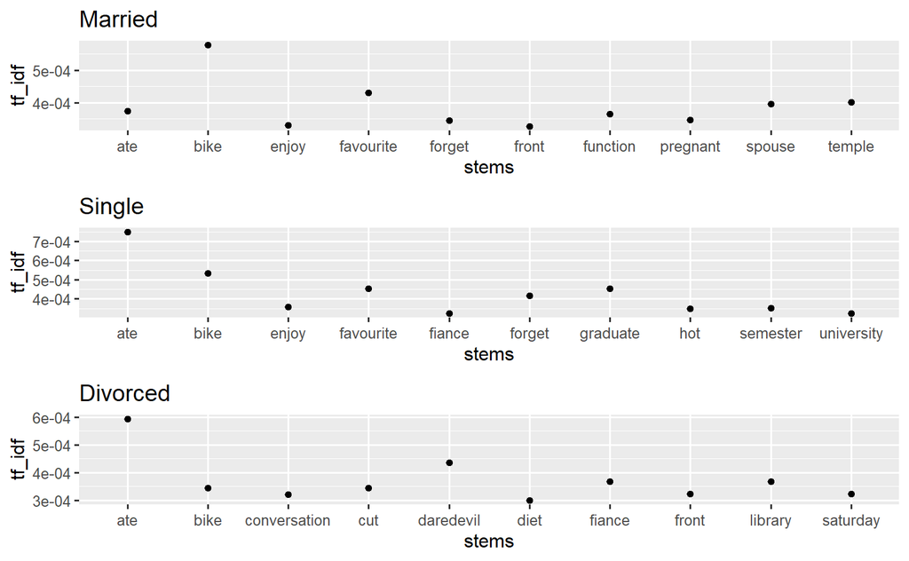

```r
p1=ggplot(mmfinal[1:10,],aes(x = stems,y=tf_idf))+geom_point()+
  ggtitle("Married")
p2=ggplot(mmfinal[11:20,],aes(x = stems,y=tf_idf))+geom_point()+
  ggtitle("Single")
p3=ggplot(mmfinal[21:30,],aes(x = stems,y=tf_idf))+geom_point()+
  ggtitle("Divorced")
ggarrange(p1,p2,p3,ncol = 1,nrow =3,widths = c(1,1),heights = c(1,1,1))
```

## People with different marital statuses also have different definitions of happy moments. For example, married individuals may find happiness in being “pregnant” or spending time with their “spouse.” Meanwhile, single individuals may still be in “university,” so graduating or having a good “semester” can bring them happiness. Divorced individuals may prefer going to the “library” and enjoying their “Saturday” in their own way.

## 4.group by whether being a parent

```r
data_p = as.data.frame(matrix(nrow=96362,ncol=2))
data_p[,1]=clear_data$parenthood
data_p[,2]=clear_data$hm

GID <- data_p$V1[!duplicated(data_p$V1)]
GO <- matrix(NA,nrow=length(GID),ncol=2)
for (i in 1:length(GID)) {
  a <- data_p[data_p$V1==GID[i],]
  GO[i,1] <- a[1,1]
  GO[i,2] <- paste(a[,2],collapse = ",")
}
GO_p<- as.data.frame(GO)

corpus_p=VCorpus(VectorSource(GO_p$V2))

list_p=corpus_p%>%
  tidy()%>%
  select(text)

dict_p <- tidy(corpus_p) %>%
  select(text) %>%
  unnest_tokens(dictionary, text)
completed_p <- list_p %>%
  mutate(id = row_number()) %>%
  distinct()%>%
  unnest_tokens(stems, text)%>%
  bind_cols(dict_g) %>%
  anti_join(stopwords, by = c("dictionary" = "word"))
completed_p$dictionary<-NULL

p_1=as.data.frame(table(completed_p[completed_p$id==1,2]))
p1_1=left_join(completed_p[completed_p$id==1,],p_1,
               by='stems')

p_2=as.data.frame(table(completed_p[completed_p$id==2,2]))
p1_2=left_join(completed_p[completed_p$id==2,],p_2,
               by='stems')

pp=rbind.data.frame(p1_1,p1_2)
pp=pp[!duplicated(pp), ]
pp %>%
  bind_tf_idf(term = stems,document = id,n = Freq) -> tf_idf_pp

tf_idf_pp=tf_idf_pp[tf_idf_pp$stems!='8th',]
tf_idf_pp=tf_idf_pp[tf_idf_pp$stems!='ï',]

tf_idf_pp%>%
  group_by(id) %>%
  arrange(desc(tf_idf))%>%
  slice(1:10) ->ppfinal
ppfinal
```

| id | stems | Freq | tf | idf | tf_idf |
| --- | --- | --- | --- | --- | --- |
| 1 | grandchildren | 15 | 6.117380e-05 | 0.6931472 | 4.240245e-05 |
| 1 | grandkids | 14 | 5.709555e-05 | 0.6931472 | 3.957562e-05 |
| 1 | circus | 9 | 3.670428e-05 | 0.6931472 | 2.544147e-05 |
| 1 | laws | 9 | 3.670428e-05 | 0.6931472 | 2.544147e-05 |
| 1 | jungle | 8 | 3.262603e-05 | 0.6931472 | 2.261464e-05 |
| 1 | pedicure | 8 | 3.262603e-05 | 0.6931472 | 2.261464e-05 |
| 1 | lacrosse | 8 | 3.262603e-05 | 0.6931472 | 2.261464e-05 |
| 1 | wayanad | 8 | 3.262603e-05 | 0.6931472 | 2.261464e-05 |
| 1 | thinkers | 7 | 2.854777e-05 | 0.6931472 | 1.978781e-05 |
| 1 | tearsmy | 7 | 2.854777e-05 | 0.6931472 | 1.978781e-05 |

[output cut: 10 more lines]

## The table above provides the top ten words in each category based on their TF-IDF scores.

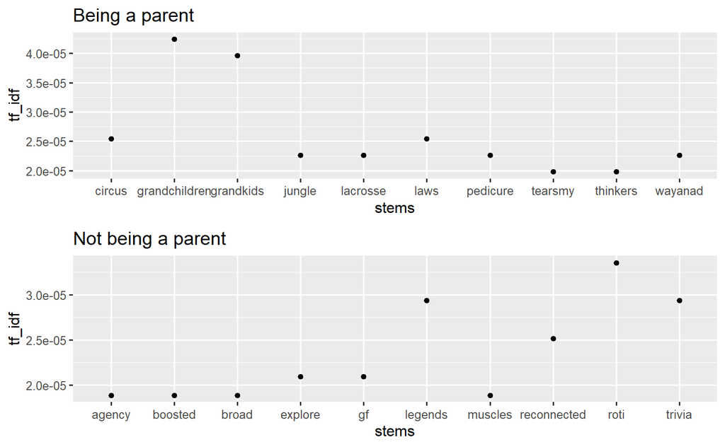

```r
p1=ggplot(ppfinal[1:10,],aes(x = stems,y=tf_idf))+geom_point()+
  ggtitle("Being a parent")
p2=ggplot(ppfinal[11:20,],aes(x = stems,y=tf_idf))+geom_point()+
  ggtitle("Not being a parent")
ggarrange(p1,p2,ncol = 1,nrow =2,widths = c(1,1),heights = c(1,1,1))
```

## Next, we will divide the population into whether they have become parents. It can be seen that for those who have become parents, spending time with their “grandchildren” in the “jungle” or playing “lacrosse” brings them happiness. On the other hand, for those who have not become parents, they prefer doing their own activities, such as exercising their “muscles” or having a meal of “roti.”

## 5.group by age

```r
clear_data[clear_data$age<25,]$age=1
clear_data[clear_data$age<55&25<=clear_data$age,]$age=2
clear_data[55<=clear_data$age,]$age=3

data_a = as.data.frame(matrix(nrow=96362,ncol=2))
data_a[,1]=clear_data$age
data_a[,2]=clear_data$hm

GID <- data_a$V1[!duplicated(data_a$V1)]
GO <- matrix(NA,nrow=length(GID),ncol=2)
for (i in 1:length(GID)) {
  a <- data_a[data_a$V1==GID[i],]
  GO[i,1] <- a[1,1]
  GO[i,2] <- paste(a[,2],collapse = ",")
}
GO_a <- as.data.frame(GO)

corpus_a=VCorpus(VectorSource(GO_a$V2))

list_a=corpus_a%>%
  tidy()%>%
  select(text)

dict_a <- tidy(corpus_a) %>%
  select(text) %>%
  unnest_tokens(dictionary, text)
completed_a <- list_a %>%
  mutate(id = row_number()) %>%
  distinct()%>%
  unnest_tokens(stems, text)%>%
  bind_cols(dict_a) %>%
  anti_join(stopwords, by = c("dictionary" = "word"))
completed_a$dictionary<-NULL

a_1=as.data.frame(table(completed_a[completed_a$id==1,2]))
a1_1=left_join(completed_a[completed_a$id==1,],a_1,
               by='stems')

a_2=as.data.frame(table(completed_a[completed_a$id==2,2]))
a1_2=left_join(completed_a[completed_a$id==2,],a_2,
               by='stems')

a_3=as.data.frame(table(completed_a[completed_a$id==3,2]))
a1_3=left_join(completed_a[completed_a$id==3,],a_3,
               by='stems')

aa=rbind.data.frame(a1_1,a1_2)
aa=rbind.data.frame(aa,a1_3)
aa=aa[!duplicated(aa), ]
aa %>%
  bind_tf_idf(term = stems,document = id,n = Freq) -> tf_idf_aa

tf_idf_aa=tf_idf_aa[tf_idf_aa$stems!='iâ',]
tf_idf_aa=tf_idf_aa[tf_idf_aa$stems!='granddaughters',]
tf_idf_aa=tf_idf_aa[tf_idf_aa$stems!='grandsons',]

tf_idf_aa%>%
  group_by(id) %>%
  arrange(desc(tf_idf))%>%
  slice(1:10) ->aafinal
aafinal
```

| id | stems | Freq | tf | idf | tf_idf |
| --- | --- | --- | --- | --- | --- |
| 1 | fiance | 185 | 4.150048e-04 | 0.4054651 | 1.682700e-04 |
| 1 | favourite | 158 | 3.544365e-04 | 0.4054651 | 1.437116e-04 |
| 1 | previous | 134 | 3.005981e-04 | 0.4054651 | 1.218820e-04 |
| 1 | daycare | 44 | 9.870384e-05 | 1.0986123 | 1.084373e-04 |
| 1 | roti | 43 | 9.646057e-05 | 1.0986123 | 1.059728e-04 |
| 1 | virtue | 42 | 9.421730e-05 | 1.0986123 | 1.035083e-04 |
| 1 | guitar | 112 | 2.512461e-04 | 0.4054651 | 1.018715e-04 |
| 1 | unforgettable | 95 | 2.131106e-04 | 0.4054651 | 8.640890e-05 |
| 1 | conference | 93 | 2.086240e-04 | 0.4054651 | 8.458976e-05 |
| 1 | wifes | 91 | 2.041375e-04 | 0.4054651 | 8.277063e-05 |

[output cut: 20 more lines]

## The table above provides the top ten words in each category based on their TF-IDF scores.

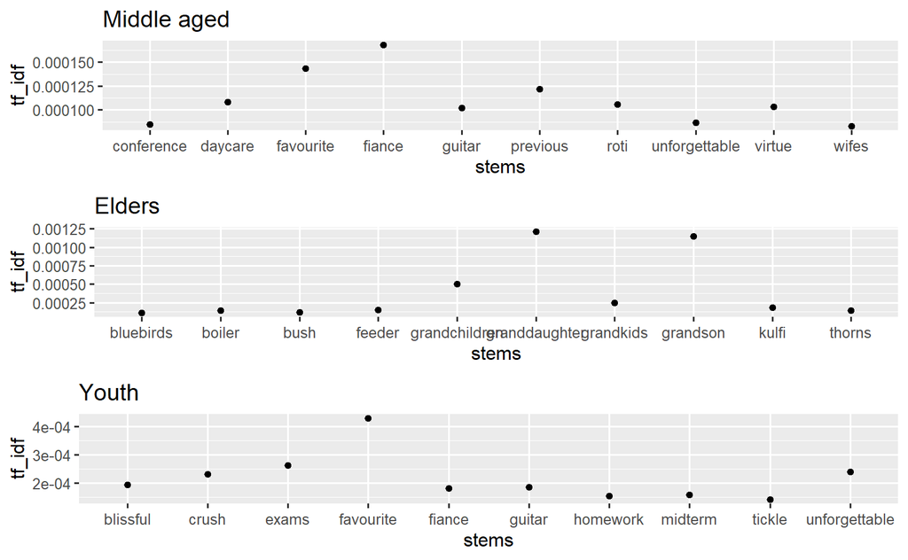

```r
a1=ggplot(aafinal[1:10,],aes(x = stems,y=tf_idf))+geom_point()+
  ggtitle("Middle aged")
a2=ggplot(aafinal[11:20,],aes(x = stems,y=tf_idf))+geom_point()+
  ggtitle("Elders")
a3=ggplot(aafinal[21:30,],aes(x = stems,y=tf_idf))+geom_point()+
  ggtitle("Youth")
ggarrange(a1,a2,a3,ncol = 1,nrow =3,widths = c(1,1),heights = c(1,1,1))
```